# Question 2

```python
# import libraries

import pandas as pd
import numpy as np
import matplotlib.pyplot as plt
```

```python
# read all files
claims_1 = pd.read_csv('Medicare_Claims_data_part_1.csv')
claims_2 = pd.read_csv('Medicare_Claims_data_part_2.csv')
claims_3 = pd.read_csv('Medicare_Claims_data_part_3.csv')
claims_4 = pd.read_csv('Medicare_Claims_data_part_4.csv')
claims_5 = pd.read_csv('Medicare_Claims_data_part_5.csv')
hcp_data = pd.read_csv('HCP_demographics_data.csv')
patient_data = pd.read_csv('Patient_demographics_data.csv')
diagnosis_data = pd.read_csv('Diagnosis_Code_Mapping.csv')
zip_data = pd.read_csv('Zip_to_Territory_Mapping.csv')
```

```python
# merge all claims data
claims_data = pd.concat([claims_1, claims_2, claims_3, claims_4, claims_5], axis=0)
claims_data.shape
```

```
(1000000, 17)
```

```python
# Overview of null values
claims_data.isnull().sum()
```

```
cur_clm_uniq_id                      0
bene_mbi_id                          0
fac_prvdr_npi_num                  930
clm_from_dt                          0
clm_thru_dt                          0
prncpl_dgns_cd                     105
clm_pmt_amt                     588330
clm_mdcr_instnl_tot_chrg_amt    580005
clm_line_num                     54451
clm_line_hcpcs_cd                 6875
clm_line_cvrd_pd_amt             56486
clm_val_sqnc_num_dgns           602835
clm_dgns_cd                         13
clm_val_sqnc_num_prcdr          957147
clm_prcdr_cd                    956968
clm_line_alowd_chrg_amt         414125
clm_prvdr_spclty_cd             441575
dtype: int64
```

```python
claims_data.head()
```

|  | cur_clm_uniq_id | bene_mbi_id | fac_prvdr_npi_num | clm_from_dt | clm_thru_dt | prncpl_dgns_cd | clm_pmt_amt | clm_mdcr_instnl_tot_chrg_amt | clm_line_num | clm_line_hcpcs_cd | clm_line_cvrd_pd_amt | clm_val_sqnc_num_dgns | clm_dgns_cd | clm_val_sqnc_num_prcdr | clm_prcdr_cd | clm_line_alowd_chrg_amt | clm_prvdr_spclty_cd |
| --- | --- | --- | --- | --- | --- | --- | --- | --- | --- | --- | --- | --- | --- | --- | --- | --- | --- |
| 0 | 1272380 | 10791 | 1.316539e+09 | 11/8/2016 | 11/7/2016 | S81811D | 154.73 | 11182.21567 | 11.0 | G8996 | -0.04 | 12.0 | Z951 | NaN | NaN | NaN | NaN |
| 1 | 631196 | 10107 | 1.033202e+09 | 7/21/2016 | 7/12/2016 | S0083XA | NaN | NaN | 1.0 | 76700 | 2.57 | NaN | I10 | NaN | NaN | 8.86 | 69 |
| 2 | 1548564 | 10412 | 1.880497e+09 | 7/14/2018 | 5/20/2018 | R918 | NaN | NaN | 1.0 | C1751 | 53.81 | NaN | I10 | NaN | NaN | 86.40 | 30 |
| 3 | 1427731 | 10934 | 1.655569e+09 | 6/19/2016 | 7/15/2016 | I2119 | 705.89 | 20750.00517 | 17.0 | 85378 | -5.91 | 7.0 | M25552 | NaN | NaN | NaN | NaN |
| 4 | 428779 | 965 | 1.644309e+09 | 3/21/2017 | 8/10/2018 | C4490 | 2884.15 | 18437.66432 | 5.0 | 80061 | 2.62 | 6.0 | Z9049 | NaN | NaN | NaN | NaN |

```python
# check number of times a claim id occurs to understand if claims are entirely unique or not
claims_data['cur_clm_uniq_id'].value_counts()
```

```
100020     2222
1699222     859
736187        7
784648        7
312510        7
           ...
762473        1
791291        1
177138        1
1061983       1
309023        1
Name: cur_clm_uniq_id, Length: 728619, dtype: int64
```

```python
# HCPCS codes of all products
product_codes = ['J1885','J2250','J3010','J2704']
```

```python
# Filter claims based on product HCPCS code
claims_data[claims_data['clm_line_hcpcs_cd'].isin(product_codes)].shape
```

```
(15268, 17)
```

```python
# Get a list of unique claim ids that use the product
claim_ids = claims_data[claims_data['clm_line_hcpcs_cd'].isin(product_codes)]['cur_clm_uniq_id'].unique()
```

```python
filtered_claims = claims_data[claims_data['cur_clm_uniq_id'].isin(claim_ids)]
filtered_claims.shape
```

```
(28368, 17)
```

```python
cols = ['cur_clm_uniq_id','bene_mbi_id','fac_prvdr_npi_num','clm_from_dt','clm_dgns_cd','clm_line_hcpcs_cd']
filtered_claims = filtered_claims[cols]
filtered_claims
```

|  | cur_clm_uniq_id | bene_mbi_id | fac_prvdr_npi_num | clm_from_dt | clm_dgns_cd | clm_line_hcpcs_cd |
| --- | --- | --- | --- | --- | --- | --- |
| 171632 | 300876 | 12388 | 7.348084e+09 | 6/3/2018 | I10 | J3010 |
| 171633 | 657288 | 11556 | 2.202143e+09 | 6/3/2016 | Z7901 | J1885 |
| 171634 | 450553 | 12021 | 5.004034e+09 | 10/4/2018 | K921 | 99283 |
| 171635 | 277076 | 10815 | 4.368806e+09 | 12/12/2016 | I10 | J3010 |
| 171636 | 476863 | 13224 | 5.200262e+09 | 6/21/2016 | Z9861 | 80048 |
| ... | ... | ... | ... | ... | ... | ... |
| 199995 | 842577 | 27 | 2.094819e+09 | 7/15/2016 | E785 | J1885 |
| 199996 | 309023 | 11454 | 4.138986e+09 | 4/24/2018 | I10 | J3010 |
| 199997 | 568041 | 10869 | 5.314549e+09 | 1/17/2018 | I10 | 17004 |
| 199998 | 100020 | 10784 | 5.599719e+09 | 12/23/2016 | I10 | J1030 |
| 199999 | 1645172 | 11429 | 7.218513e+09 | 7/28/2017 | Z131 | A9561 |

28368 rows × 6 columns

```python
filtered_claims = filtered_claims.reset_index(drop=True)
filtered_claims
```

|  | cur_clm_uniq_id | bene_mbi_id | fac_prvdr_npi_num | clm_from_dt | clm_dgns_cd | clm_line_hcpcs_cd |
| --- | --- | --- | --- | --- | --- | --- |
| 0 | 300876 | 12388 | 7.348084e+09 | 6/3/2018 | I10 | J3010 |
| 1 | 657288 | 11556 | 2.202143e+09 | 6/3/2016 | Z7901 | J1885 |
| 2 | 450553 | 12021 | 5.004034e+09 | 10/4/2018 | K921 | 99283 |
| 3 | 277076 | 10815 | 4.368806e+09 | 12/12/2016 | I10 | J3010 |
| 4 | 476863 | 13224 | 5.200262e+09 | 6/21/2016 | Z9861 | 80048 |
| ... | ... | ... | ... | ... | ... | ... |
| 28363 | 842577 | 27 | 2.094819e+09 | 7/15/2016 | E785 | J1885 |
| 28364 | 309023 | 11454 | 4.138986e+09 | 4/24/2018 | I10 | J3010 |
| 28365 | 568041 | 10869 | 5.314549e+09 | 1/17/2018 | I10 | 17004 |
| 28366 | 100020 | 10784 | 5.599719e+09 | 12/23/2016 | I10 | J1030 |
| 28367 | 1645172 | 11429 | 7.218513e+09 | 7/28/2017 | Z131 | A9561 |

28368 rows × 6 columns

```python
diagnosis_data.head()
```

|  | Diagnosis Code Market | Specialty |
| --- | --- | --- |
| 0 | A | Infectious and Parasitic Diseases |
| 1 | B | Infectious and Parasitic Diseases |
| 2 | C | Neoplasms |
| 3 | D | Neoplasms, Blood, Blood-forming Organs |
| 4 | E | Endocrine, Nutritional, Metabolic |

```python
filtered_claims['Diagnosis Code Market'] = filtered_claims['clm_dgns_cd'].str[0]
filtered_claims = filtered_claims.merge(diagnosis_data,on='Diagnosis Code Market',how='left')
filtered_claims
```

|  | cur_clm_uniq_id | bene_mbi_id | fac_prvdr_npi_num | clm_from_dt | clm_dgns_cd | clm_line_hcpcs_cd | Diagnosis Code Market | Specialty |
| --- | --- | --- | --- | --- | --- | --- | --- | --- |
| 0 | 300876 | 12388 | 7.348084e+09 | 6/3/2018 | I10 | J3010 | I | Circulatory System |
| 1 | 657288 | 11556 | 2.202143e+09 | 6/3/2016 | Z7901 | J1885 | Z | Factors Influencing Health Status and Contact ... |
| 2 | 450553 | 12021 | 5.004034e+09 | 10/4/2018 | K921 | 99283 | K | Digestive System |
| 3 | 277076 | 10815 | 4.368806e+09 | 12/12/2016 | I10 | J3010 | I | Circulatory System |
| 4 | 476863 | 13224 | 5.200262e+09 | 6/21/2016 | Z9861 | 80048 | Z | Factors Influencing Health Status and Contact ... |
| ... | ... | ... | ... | ... | ... | ... | ... | ... |
| 28363 | 842577 | 27 | 2.094819e+09 | 7/15/2016 | E785 | J1885 | E | Endocrine, Nutritional, Metabolic |
| 28364 | 309023 | 11454 | 4.138986e+09 | 4/24/2018 | I10 | J3010 | I | Circulatory System |
| 28365 | 568041 | 10869 | 5.314549e+09 | 1/17/2018 | I10 | 17004 | I | Circulatory System |
| 28366 | 100020 | 10784 | 5.599719e+09 | 12/23/2016 | I10 | J1030 | I | Circulatory System |
| 28367 | 1645172 | 11429 | 7.218513e+09 | 7/28/2017 | Z131 | A9561 | Z | Factors Influencing Health Status and Contact ... |

28368 rows × 8 columns

```python
filtered_claims = filtered_claims.rename(columns={'Specialty':'Specialty Of Diagnosis'})
filtered_claims
```

|  | cur_clm_uniq_id | bene_mbi_id | fac_prvdr_npi_num | clm_from_dt | clm_dgns_cd | clm_line_hcpcs_cd | Diagnosis Code Market | Specialty Of Diagnosis |
| --- | --- | --- | --- | --- | --- | --- | --- | --- |
| 0 | 300876 | 12388 | 7.348084e+09 | 6/3/2018 | I10 | J3010 | I | Circulatory System |
| 1 | 657288 | 11556 | 2.202143e+09 | 6/3/2016 | Z7901 | J1885 | Z | Factors Influencing Health Status and Contact ... |
| 2 | 450553 | 12021 | 5.004034e+09 | 10/4/2018 | K921 | 99283 | K | Digestive System |
| 3 | 277076 | 10815 | 4.368806e+09 | 12/12/2016 | I10 | J3010 | I | Circulatory System |
| 4 | 476863 | 13224 | 5.200262e+09 | 6/21/2016 | Z9861 | 80048 | Z | Factors Influencing Health Status and Contact ... |
| ... | ... | ... | ... | ... | ... | ... | ... | ... |
| 28363 | 842577 | 27 | 2.094819e+09 | 7/15/2016 | E785 | J1885 | E | Endocrine, Nutritional, Metabolic |
| 28364 | 309023 | 11454 | 4.138986e+09 | 4/24/2018 | I10 | J3010 | I | Circulatory System |
| 28365 | 568041 | 10869 | 5.314549e+09 | 1/17/2018 | I10 | 17004 | I | Circulatory System |
| 28366 | 100020 | 10784 | 5.599719e+09 | 12/23/2016 | I10 | J1030 | I | Circulatory System |
| 28367 | 1645172 | 11429 | 7.218513e+09 | 7/28/2017 | Z131 | A9561 | Z | Factors Influencing Health Status and Contact ... |

28368 rows × 8 columns

```python
filtered_claims.drop('Diagnosis Code Market',axis=1,inplace=True)
```

```python
filtered_claims
```

|  | cur_clm_uniq_id | bene_mbi_id | fac_prvdr_npi_num | clm_from_dt | clm_dgns_cd | clm_line_hcpcs_cd | Specialty Of Diagnosis |
| --- | --- | --- | --- | --- | --- | --- | --- |
| 0 | 300876 | 12388 | 7.348084e+09 | 6/3/2018 | I10 | J3010 | Circulatory System |
| 1 | 657288 | 11556 | 2.202143e+09 | 6/3/2016 | Z7901 | J1885 | Factors Influencing Health Status and Contact ... |
| 2 | 450553 | 12021 | 5.004034e+09 | 10/4/2018 | K921 | 99283 | Digestive System |
| 3 | 277076 | 10815 | 4.368806e+09 | 12/12/2016 | I10 | J3010 | Circulatory System |
| 4 | 476863 | 13224 | 5.200262e+09 | 6/21/2016 | Z9861 | 80048 | Factors Influencing Health Status and Contact ... |
| ... | ... | ... | ... | ... | ... | ... | ... |
| 28363 | 842577 | 27 | 2.094819e+09 | 7/15/2016 | E785 | J1885 | Endocrine, Nutritional, Metabolic |
| 28364 | 309023 | 11454 | 4.138986e+09 | 4/24/2018 | I10 | J3010 | Circulatory System |
| 28365 | 568041 | 10869 | 5.314549e+09 | 1/17/2018 | I10 | 17004 | Circulatory System |
| 28366 | 100020 | 10784 | 5.599719e+09 | 12/23/2016 | I10 | J1030 | Circulatory System |
| 28367 | 1645172 | 11429 | 7.218513e+09 | 7/28/2017 | Z131 | A9561 | Factors Influencing Health Status and Contact ... |

28368 rows × 7 columns

```python
hcp_data.head()
```

|  | HCP NPI ID | Address | City | State | ZIP Code | Specialty |
| --- | --- | --- | --- | --- | --- | --- |
| 0 | 8386928704 | 322 Roberts Drive Suite 888 | South Shannonton | AS | 67431 | Neurology |
| 1 | 3688956922 | 11734 Deanna Groves Suite 031 | Leviburgh | OK | 12405 | Anesthesiology |
| 2 | 5134290518 | 18686 Schwartz Streets | Shepherdstad | RI | 97054 | Neurology |
| 3 | 6740392080 | 410 Woodard Drive Suite 766 | East Calvinmouth | MA | 92138 | Gastroenterology |
| 4 | 1178012810 | 83203 Jimenez Village Apt. 548 | Griffinchester | WY | 48202 | Anesthesiology |

```python
hcp_data = hcp_data.rename(columns={'HCP NPI ID': 'fac_prvdr_npi_num'})
hcp_data
```

|  | fac_prvdr_npi_num | Address | City | State | ZIP Code | Specialty |
| --- | --- | --- | --- | --- | --- | --- |
| 0 | 8386928704 | 322 Roberts Drive Suite 888 | South Shannonton | AS | 67431 | Neurology |
| 1 | 3688956922 | 11734 Deanna Groves Suite 031 | Leviburgh | OK | 12405 | Anesthesiology |
| 2 | 5134290518 | 18686 Schwartz Streets | Shepherdstad | RI | 97054 | Neurology |
| 3 | 6740392080 | 410 Woodard Drive Suite 766 | East Calvinmouth | MA | 92138 | Gastroenterology |
| 4 | 1178012810 | 83203 Jimenez Village Apt. 548 | Griffinchester | WY | 48202 | Anesthesiology |
| ... | ... | ... | ... | ... | ... | ... |
| 1995 | 7648402660 | 1207 Olivia Via | Phillipfort | UT | 81154 | Anesthesiology |
| 1996 | 5530159315 | 86116 Mathews Track Suite 253 | Port Scott | TN | 7721 | Gastroenterology |
| 1997 | 2202122399 | 070 Monica Loop | Haydenmouth | MD | 98386 | Cardiology |
| 1998 | 6175046381 | 5842 George Roads Suite 456 | Changchester | GA | 98013 | Gastroenterology |
| 1999 | 2075389828 | 36286 Rodney Field | Stephenshire | ND | 53946 | Anesthesiology |

2000 rows × 6 columns

```python
filtered_claims = filtered_claims.merge(hcp_data,on='fac_prvdr_npi_num',how='left')
filtered_claims
```

|  | cur_clm_uniq_id | bene_mbi_id | fac_prvdr_npi_num | clm_from_dt | clm_dgns_cd | clm_line_hcpcs_cd | Specialty Of Diagnosis | Address | City | State | ZIP Code | Specialty |
| --- | --- | --- | --- | --- | --- | --- | --- | --- | --- | --- | --- | --- |
| 0 | 300876 | 12388 | 7.348084e+09 | 6/3/2018 | I10 | J3010 | Circulatory System | 01683 Garcia Terrace | West Ronaldmouth | MH | 10164 | Anesthesiology |
| 1 | 657288 | 11556 | 2.202143e+09 | 6/3/2016 | Z7901 | J1885 | Factors Influencing Health Status and Contact ... | 698 Reynolds Lake | Petersonside | WI | 38050 | Anesthesiology |
| 2 | 450553 | 12021 | 5.004034e+09 | 10/4/2018 | K921 | 99283 | Digestive System | 879 Paul Cove Suite 764 | Williamchester | WV | 20012 | Cardiology |
| 3 | 277076 | 10815 | 4.368806e+09 | 12/12/2016 | I10 | J3010 | Circulatory System | 920 Christine Ways Apt. 006 | South Travis | AL | 51355 | Cardiology |
| 4 | 476863 | 13224 | 5.200262e+09 | 6/21/2016 | Z9861 | 80048 | Factors Influencing Health Status and Contact ... | 383 Jennings Corners Apt. 259 | Morrisshire | MT | 76859 | Anesthesiology |
| ... | ... | ... | ... | ... | ... | ... | ... | ... | ... | ... | ... | ... |
| 28363 | 842577 | 27 | 2.094819e+09 | 7/15/2016 | E785 | J1885 | Endocrine, Nutritional, Metabolic | 2663 Matthew Ferry Suite 639 | Lake Courtneyport | KS | 20913 | Gastroenterology |
| 28364 | 309023 | 11454 | 4.138986e+09 | 4/24/2018 | I10 | J3010 | Circulatory System | 48246 Holly Course Apt. 630 | Grahamton | CO | 39564 | Anesthesiology |
| 28365 | 568041 | 10869 | 5.314549e+09 | 1/17/2018 | I10 | 17004 | Circulatory System | 36717 Jenkins Freeway | New Morgan | DC | 74136 | Cardiology |
| 28366 | 100020 | 10784 | 5.599719e+09 | 12/23/2016 | I10 | J1030 | Circulatory System | 845 Garcia Mount | Williamberg | VT | 4765 | Anesthesiology |
| 28367 | 1645172 | 11429 | 7.218513e+09 | 7/28/2017 | Z131 | A9561 | Factors Influencing Health Status and Contact ... | 162 Evans Rapid Suite 693 | North Kimberly | KS | 27325 | Gastroenterology |

28368 rows × 12 columns

```python
patient_data.head()
```

|  | Patient_id | Age | Gender |
| --- | --- | --- | --- |
| 0 | 10 | 71 | Male |
| 1 | 11 | 56 | Male |
| 2 | 12 | 65 | Female |
| 3 | 13 | 72 | Female |
| 4 | 14 | 77 | Female |

```python
patient_data = patient_data.rename(columns={'Patient_id':'bene_mbi_id'})
patient_data
```

|  | bene_mbi_id | Age | Gender |
| --- | --- | --- | --- |
| 0 | 10 | 71 | Male |
| 1 | 11 | 56 | Male |
| 2 | 12 | 65 | Female |
| 3 | 13 | 72 | Female |
| 4 | 14 | 77 | Female |
| ... | ... | ... | ... |
| 4503 | 13376 | 64 | Female |
| 4504 | 13377 | 60 | Male |
| 4505 | 13378 | 23 | Female |
| 4506 | 13379 | 90 | Female |
| 4507 | 13380 | 69 | Female |

4508 rows × 3 columns

```python
filtered_claims = filtered_claims.merge(patient_data,on='bene_mbi_id',how='left')
filtered_claims
```

|  | cur_clm_uniq_id | bene_mbi_id | fac_prvdr_npi_num | clm_from_dt | clm_dgns_cd | clm_line_hcpcs_cd | Specialty Of Diagnosis | Address | City | State | ZIP Code | Specialty | Age | Gender |
| --- | --- | --- | --- | --- | --- | --- | --- | --- | --- | --- | --- | --- | --- | --- |
| 0 | 300876 | 12388 | 7.348084e+09 | 6/3/2018 | I10 | J3010 | Circulatory System | 01683 Garcia Terrace | West Ronaldmouth | MH | 10164 | Anesthesiology | 18 | Female |
| 1 | 657288 | 11556 | 2.202143e+09 | 6/3/2016 | Z7901 | J1885 | Factors Influencing Health Status and Contact ... | 698 Reynolds Lake | Petersonside | WI | 38050 | Anesthesiology | 61 | Female |
| 2 | 450553 | 12021 | 5.004034e+09 | 10/4/2018 | K921 | 99283 | Digestive System | 879 Paul Cove Suite 764 | Williamchester | WV | 20012 | Cardiology | 26 | Male |
| 3 | 277076 | 10815 | 4.368806e+09 | 12/12/2016 | I10 | J3010 | Circulatory System | 920 Christine Ways Apt. 006 | South Travis | AL | 51355 | Cardiology | 65 | Male |
| 4 | 476863 | 13224 | 5.200262e+09 | 6/21/2016 | Z9861 | 80048 | Factors Influencing Health Status and Contact ... | 383 Jennings Corners Apt. 259 | Morrisshire | MT | 76859 | Anesthesiology | 37 | Female |
| ... | ... | ... | ... | ... | ... | ... | ... | ... | ... | ... | ... | ... | ... | ... |
| 28363 | 842577 | 27 | 2.094819e+09 | 7/15/2016 | E785 | J1885 | Endocrine, Nutritional, Metabolic | 2663 Matthew Ferry Suite 639 | Lake Courtneyport | KS | 20913 | Gastroenterology | 75 | Female |
| 28364 | 309023 | 11454 | 4.138986e+09 | 4/24/2018 | I10 | J3010 | Circulatory System | 48246 Holly Course Apt. 630 | Grahamton | CO | 39564 | Anesthesiology | 84 | Female |
| 28365 | 568041 | 10869 | 5.314549e+09 | 1/17/2018 | I10 | 17004 | Circulatory System | 36717 Jenkins Freeway | New Morgan | DC | 74136 | Cardiology | 82 | Female |
| 28366 | 100020 | 10784 | 5.599719e+09 | 12/23/2016 | I10 | J1030 | Circulatory System | 845 Garcia Mount | Williamberg | VT | 4765 | Anesthesiology | 33 | Male |
| 28367 | 1645172 | 11429 | 7.218513e+09 | 7/28/2017 | Z131 | A9561 | Factors Influencing Health Status and Contact ... | 162 Evans Rapid Suite 693 | North Kimberly | KS | 27325 | Gastroenterology | 73 | Male |

28368 rows × 14 columns

```python
# Ensure zip codes are in 5-digit string format
filtered_claims['ZIP Code'] = filtered_claims['ZIP Code'].astype(str).str.zfill(5)
zip_data['Zip Code'] = zip_data['Zip Code'].astype(str).str.zfill(5)
```

```python
filtered_claims.rename(columns={'ZIP Code':'Zip Code'},inplace=True)
```

```python
filtered_claims.head()
```

|  | cur_clm_uniq_id | bene_mbi_id | fac_prvdr_npi_num | clm_from_dt | clm_dgns_cd | clm_line_hcpcs_cd | Specialty Of Diagnosis | Address | City | State | Zip Code | Specialty | Age | Gender |
| --- | --- | --- | --- | --- | --- | --- | --- | --- | --- | --- | --- | --- | --- | --- |
| 0 | 300876 | 12388 | 7.348084e+09 | 6/3/2018 | I10 | J3010 | Circulatory System | 01683 Garcia Terrace | West Ronaldmouth | MH | 10164 | Anesthesiology | 18 | Female |
| 1 | 657288 | 11556 | 2.202143e+09 | 6/3/2016 | Z7901 | J1885 | Factors Influencing Health Status and Contact ... | 698 Reynolds Lake | Petersonside | WI | 38050 | Anesthesiology | 61 | Female |
| 2 | 450553 | 12021 | 5.004034e+09 | 10/4/2018 | K921 | 99283 | Digestive System | 879 Paul Cove Suite 764 | Williamchester | WV | 20012 | Cardiology | 26 | Male |
| 3 | 277076 | 10815 | 4.368806e+09 | 12/12/2016 | I10 | J3010 | Circulatory System | 920 Christine Ways Apt. 006 | South Travis | AL | 51355 | Cardiology | 65 | Male |
| 4 | 476863 | 13224 | 5.200262e+09 | 6/21/2016 | Z9861 | 80048 | Factors Influencing Health Status and Contact ... | 383 Jennings Corners Apt. 259 | Morrisshire | MT | 76859 | Anesthesiology | 37 | Female |

```python
# Perform the join
filtered_claims = filtered_claims.merge(zip_data, on='Zip Code',how='left')
filtered_claims.head()
```

|  | cur_clm_uniq_id | bene_mbi_id | fac_prvdr_npi_num | clm_from_dt | clm_dgns_cd | clm_line_hcpcs_cd | Specialty Of Diagnosis | Address | City | State | Zip Code | Specialty | Age | Gender | Territory Name | Region Name |
| --- | --- | --- | --- | --- | --- | --- | --- | --- | --- | --- | --- | --- | --- | --- | --- | --- |
| 0 | 300876 | 12388 | 7.348084e+09 | 6/3/2018 | I10 | J3010 | Circulatory System | 01683 Garcia Terrace | West Ronaldmouth | MH | 10164 | Anesthesiology | 18 | Female | St Louis, MO | Midwest |
| 1 | 657288 | 11556 | 2.202143e+09 | 6/3/2016 | Z7901 | J1885 | Factors Influencing Health Status and Contact ... | 698 Reynolds Lake | Petersonside | WI | 38050 | Anesthesiology | 61 | Female | Orlando, FL | Southeast |
| 2 | 450553 | 12021 | 5.004034e+09 | 10/4/2018 | K921 | 99283 | Digestive System | 879 Paul Cove Suite 764 | Williamchester | WV | 20012 | Cardiology | 26 | Male | Washington, D.C. | Northeast |
| 3 | 277076 | 10815 | 4.368806e+09 | 12/12/2016 | I10 | J3010 | Circulatory System | 920 Christine Ways Apt. 006 | South Travis | AL | 51355 | Cardiology | 65 | Male | New York, NY | Northeast |
| 4 | 476863 | 13224 | 5.200262e+09 | 6/21/2016 | Z9861 | 80048 | Factors Influencing Health Status and Contact ... | 383 Jennings Corners Apt. 259 | Morrisshire | MT | 76859 | Anesthesiology | 37 | Female | Charlotte, NC | Southeast |

```python
filtered_claims.rename(columns={'cur_clm_uniq_id':'Claim_ID','bene_mbi_id':'Patient_ID','fac_prvdr_npi_num':'HCP_ID','clm_from_dt':'Claim_Date','clm_dgns_cd':'Diagnosis_Code','clm_line_hcpcs_cd':'Procedure_Code'},inplace=True)
```

```python
filtered_claims.head()
```

|  | Claim_ID | Patient_ID | HCP_ID | Claim_Date | Diagnosis_Code | Procedure_Code | Specialty Of Diagnosis | Address | City | State | Zip Code | Specialty | Age | Gender | Territory Name | Region Name |
| --- | --- | --- | --- | --- | --- | --- | --- | --- | --- | --- | --- | --- | --- | --- | --- | --- |
| 0 | 300876 | 12388 | 7.348084e+09 | 6/3/2018 | I10 | J3010 | Circulatory System | 01683 Garcia Terrace | West Ronaldmouth | MH | 10164 | Anesthesiology | 18 | Female | St Louis, MO | Midwest |
| 1 | 657288 | 11556 | 2.202143e+09 | 6/3/2016 | Z7901 | J1885 | Factors Influencing Health Status and Contact ... | 698 Reynolds Lake | Petersonside | WI | 38050 | Anesthesiology | 61 | Female | Orlando, FL | Southeast |
| 2 | 450553 | 12021 | 5.004034e+09 | 10/4/2018 | K921 | 99283 | Digestive System | 879 Paul Cove Suite 764 | Williamchester | WV | 20012 | Cardiology | 26 | Male | Washington, D.C. | Northeast |
| 3 | 277076 | 10815 | 4.368806e+09 | 12/12/2016 | I10 | J3010 | Circulatory System | 920 Christine Ways Apt. 006 | South Travis | AL | 51355 | Cardiology | 65 | Male | New York, NY | Northeast |
| 4 | 476863 | 13224 | 5.200262e+09 | 6/21/2016 | Z9861 | 80048 | Factors Influencing Health Status and Contact ... | 383 Jennings Corners Apt. 259 | Morrisshire | MT | 76859 | Anesthesiology | 37 | Female | Charlotte, NC | Southeast |

```python
# Save the DataFrame to a CSV file
filtered_claims.to_csv('merged_data.csv', index=False)
```

```python
filtered_claims.isnull().sum()
```

```
Claim_ID                   0
Patient_ID                 0
HCP_ID                     0
Claim_Date                 0
Diagnosis_Code             0
Procedure_Code            99
Specialty Of Diagnosis     0
Address                    0
City                       0
State                      0
Zip Code                   0
Specialty                  0
Age                        0
Gender                     0
Territory Name             0
Region Name                0
dtype: int64
```

```python
# Analysis of null values for procedure code
filtered_claims[filtered_claims['Procedure_Code'].isnull()]['Patient_ID'].nunique()
```

```
97
```

### Identifying the trends of the Key Market Drivers of the Injectable Anesthesia Market:

```python
filtered_claims.head()
```

|  | Claim_ID | Patient_ID | HCP_ID | Claim_Date | Diagnosis_Code | Procedure_Code | Specialty Of Diagnosis | Address | City | State | Zip Code | Specialty | Age | Gender | Territory Name | Region Name |
| --- | --- | --- | --- | --- | --- | --- | --- | --- | --- | --- | --- | --- | --- | --- | --- | --- |
| 0 | 300876 | 12388 | 7.348084e+09 | 6/3/2018 | I10 | J3010 | Circulatory System | 01683 Garcia Terrace | West Ronaldmouth | MH | 10164 | Anesthesiology | 18 | Female | St Louis, MO | Midwest |
| 1 | 657288 | 11556 | 2.202143e+09 | 6/3/2016 | Z7901 | J1885 | Factors Influencing Health Status and Contact ... | 698 Reynolds Lake | Petersonside | WI | 38050 | Anesthesiology | 61 | Female | Orlando, FL | Southeast |
| 2 | 450553 | 12021 | 5.004034e+09 | 10/4/2018 | K921 | 99283 | Digestive System | 879 Paul Cove Suite 764 | Williamchester | WV | 20012 | Cardiology | 26 | Male | Washington, D.C. | Northeast |
| 3 | 277076 | 10815 | 4.368806e+09 | 12/12/2016 | I10 | J3010 | Circulatory System | 920 Christine Ways Apt. 006 | South Travis | AL | 51355 | Cardiology | 65 | Male | New York, NY | Northeast |
| 4 | 476863 | 13224 | 5.200262e+09 | 6/21/2016 | Z9861 | 80048 | Factors Influencing Health Status and Contact ... | 383 Jennings Corners Apt. 259 | Morrisshire | MT | 76859 | Anesthesiology | 37 | Female | Charlotte, NC | Southeast |

```python
# Convert Claim_Date to datetime
filtered_claims['Claim_Date'] = pd.to_datetime(filtered_claims['Claim_Date'])

# Find the earliest year
earliest_year = filtered_claims['Claim_Date'].dt.year.min()
print("Earliest Year:", earliest_year)
```

```
Earliest Year: 2015
```

```python
# Convert Claim_Date to datetime
filtered_claims['Claim_Date'] = pd.to_datetime(filtered_claims['Claim_Date'])

# Find the earliest year
earliest_year = filtered_claims['Claim_Date'].dt.year.max()
print("Latest Year:", earliest_year)
```

```
Latest Year: 2018
```

```python
claims_que_2 = filtered_claims[
    (filtered_claims['Claim_Date'].dt.year >= 2016) &
    (filtered_claims['Claim_Date'].dt.year <= 2018)]
```

```python
claims_que_2['Claim_Date'].dt.year.min()
```

```
2016
```

```python
claims_que_2['Claim_Date'].dt.year.max()
```

```
2018
```

```python
claims_que_2 = claims_que_2[claims_que_2['Procedure_Code'].isin(product_codes)]
claims_que_2['Procedure_Code'].value_counts()
```

```
J1885    10147
J3010     3263
J2250     1148
J2704      704
Name: Procedure_Code, dtype: int64
```

```python
claims_que_2.isnull().sum()
```

```
Claim_ID                  0
Patient_ID                0
HCP_ID                    0
Claim_Date                0
Diagnosis_Code            0
Procedure_Code            0
Specialty Of Diagnosis    0
Address                   0
City                      0
State                     0
Zip Code                  0
Specialty                 0
Age                       0
Gender                    0
Territory Name            0
Region Name               0
dtype: int64
```

```python
claims_que_2['Specialty Of Diagnosis'].value_counts()
```

```
Circulatory System                                                      7330
Factors Influencing Health Status and Contact with Health Services      1821
Symptoms, Signs and Abnormal Clinical and Lab Findings                  1287
Musculoskeletal and Connective Tissue                                   1195
Endocrine, Nutritional, Metabolic                                        762
Digestive System                                                         582
Genitourinary System                                                     473
Respiratory System                                                       392
Mental and Behavioral Disorders                                          292
Eye and Adnexa, Ear and Mastoid Process                                  249
Neoplasms, Blood, Blood-forming Organs                                   228
Nervous System                                                           182
Injury, Poisoning, Certain Other Consequences of External Causes         160
Neoplasms                                                                137
Skin and Subcutaneous Tissue                                              90
Infectious and Parasitic Diseases                                         70
External Causes of Morbidity                                               7
Congenital Malformations, Deformations and Chromosomal Abnormalities       5
Name: Specialty Of Diagnosis, dtype: int64
```

```python
# Aggregate claims by specialty
claims_que_2.groupby('Specialty Of Diagnosis')['Claim_ID'].nunique()
```

```
Specialty Of Diagnosis
Circulatory System                                                      7290
Congenital Malformations, Deformations and Chromosomal Abnormalities       5
Digestive System                                                         582
Endocrine, Nutritional, Metabolic                                        754
External Causes of Morbidity                                               7
Eye and Adnexa, Ear and Mastoid Process                                  249
Factors Influencing Health Status and Contact with Health Services      1818
Genitourinary System                                                     471
Infectious and Parasitic Diseases                                         70
Injury, Poisoning, Certain Other Consequences of External Causes         160
Mental and Behavioral Disorders                                          292
Musculoskeletal and Connective Tissue                                   1189
Neoplasms                                                                137
Neoplasms, Blood, Blood-forming Organs                                   228
Nervous System                                                           182
Respiratory System                                                       392
Skin and Subcutaneous Tissue                                              90
Symptoms, Signs and Abnormal Clinical and Lab Findings                  1281
Name: Claim_ID, dtype: int64
```

A pie chart showing the percentage of claims that each diagnosis specialty contributes. Extract the diagnosis code initial and map the diagnosis specialty using the diagnosis code mapping dataset. Show only the top 5 diagnosis specialties.

```python
# Drop duplicates to ensure one patient per specialty
unique_patient_specialty = claims_que_2[['Claim_ID', 'Specialty Of Diagnosis']].drop_duplicates()

# Group by Specialty
diagnosis_specialty = unique_patient_specialty.groupby('Specialty Of Diagnosis').size().reset_index(name='Claims')
diagnosis_specialty
```

|  | Specialty Of Diagnosis | Claims |
| --- | --- | --- |
| 0 | Circulatory System | 7290 |
| 1 | Congenital Malformations, Deformations and Chr... | 5 |
| 2 | Digestive System | 582 |
| 3 | Endocrine, Nutritional, Metabolic | 754 |
| 4 | External Causes of Morbidity | 7 |
| 5 | Eye and Adnexa, Ear and Mastoid Process | 249 |
| 6 | Factors Influencing Health Status and Contact ... | 1818 |
| 7 | Genitourinary System | 471 |
| 8 | Infectious and Parasitic Diseases | 70 |
| 9 | Injury, Poisoning, Certain Other Consequences ... | 160 |
| 10 | Mental and Behavioral Disorders | 292 |
| 11 | Musculoskeletal and Connective Tissue | 1189 |
| 12 | Neoplasms | 137 |
| 13 | Neoplasms, Blood, Blood-forming Organs | 228 |
| 14 | Nervous System | 182 |
| 15 | Respiratory System | 392 |
| 16 | Skin and Subcutaneous Tissue | 90 |
| 17 | Symptoms, Signs and Abnormal Clinical and Lab ... | 1281 |

```python
diagnosis_specialty['Percentage'] = (diagnosis_specialty['Claims'] / diagnosis_specialty['Claims'].sum()) * 100
diagnosis_specialty
```

|  | Specialty Of Diagnosis | Claims | Percentage |
| --- | --- | --- | --- |
| 0 | Circulatory System | 7290 | 47.969994 |
| 1 | Congenital Malformations, Deformations and Chr... | 5 | 0.032901 |
| 2 | Digestive System | 582 | 3.829703 |
| 3 | Endocrine, Nutritional, Metabolic | 754 | 4.961506 |
| 4 | External Causes of Morbidity | 7 | 0.046062 |
| 5 | Eye and Adnexa, Ear and Mastoid Process | 249 | 1.638481 |
| 6 | Factors Influencing Health Status and Contact ... | 1818 | 11.962887 |
| 7 | Genitourinary System | 471 | 3.099296 |
| 8 | Infectious and Parasitic Diseases | 70 | 0.460617 |
| 9 | Injury, Poisoning, Certain Other Consequences ... | 160 | 1.052839 |
| 10 | Mental and Behavioral Disorders | 292 | 1.921432 |
| 11 | Musculoskeletal and Connective Tissue | 1189 | 7.823913 |
| 12 | Neoplasms | 137 | 0.901494 |
| 13 | Neoplasms, Blood, Blood-forming Organs | 228 | 1.500296 |
| 14 | Nervous System | 182 | 1.197605 |
| 15 | Respiratory System | 392 | 2.579456 |
| 16 | Skin and Subcutaneous Tissue | 90 | 0.592222 |
| 17 | Symptoms, Signs and Abnormal Clinical and Lab ... | 1281 | 8.429295 |

```python
top_specialties = diagnosis_specialty.nlargest(5, 'Claims')
```

```python
top_specialties
```

|  | Specialty Of Diagnosis | Claims | Percentage |
| --- | --- | --- | --- |
| 0 | Circulatory System | 7290 | 47.969994 |
| 6 | Factors Influencing Health Status and Contact ... | 1818 | 11.962887 |
| 17 | Symptoms, Signs and Abnormal Clinical and Lab ... | 1281 | 8.429295 |
| 11 | Musculoskeletal and Connective Tissue | 1189 | 7.823913 |
| 3 | Endocrine, Nutritional, Metabolic | 754 | 4.961506 |

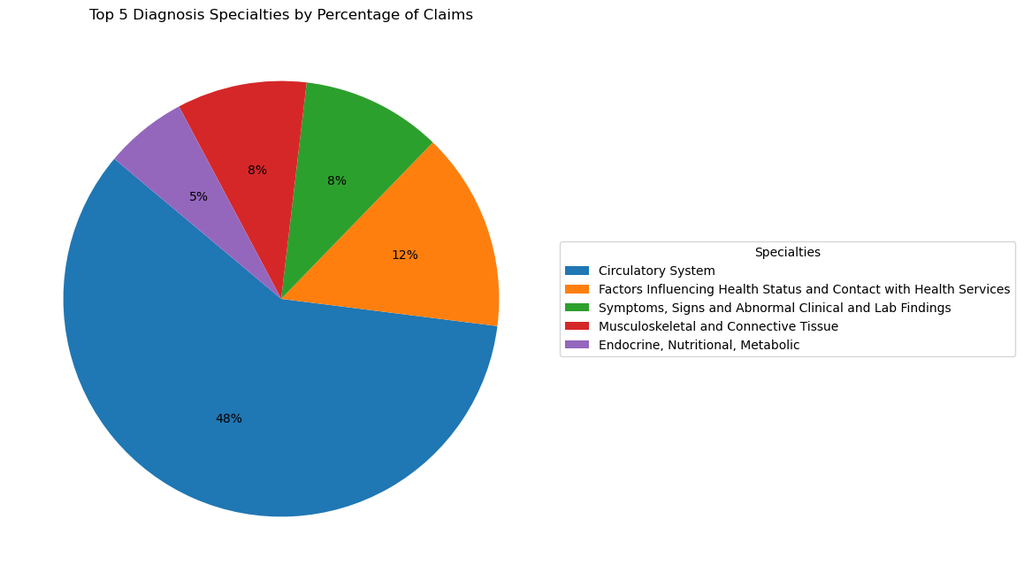

```python
import matplotlib.pyplot as plt

plt.figure(figsize=(8, 8))
# Creating the pie chart
wedges, texts, autotexts = plt.pie(
    top_specialties['Percentage'],
    labels=None,  # Labels are removed from the pie slices for cleaner visuals
    autopct=lambda p: f'{p * sum(top_specialties["Percentage"]) / 100:.0f}%',
    startangle=140
)

# Adding a legend
plt.legend(
    wedges,
    top_specialties['Specialty Of Diagnosis'],
    title="Specialties",
    loc="center left",
    bbox_to_anchor=(1, 0.5)
)

plt.title("Top 5 Diagnosis Specialties by Percentage of Claims")
plt.show()
```

### Observations and Insights from the Charts

#### **Pie Chart: Top 5 Diagnosis Specialties by Percentage of Claims**

- **Circulatory System (48%)**:
  - This is the dominant diagnosis specialty, contributing nearly half of the claims. It indicates that patients undergoing procedures related to circulatory issues (e.g., cardiovascular surgeries) are the primary target demographic.
- **Factors Influencing Health Status (12%)**:
  - This category represents general health issues, likely including preoperative procedures. Its significant share highlights a broader usage of anesthesia across diverse settings.
- **Symptoms and Abnormal Findings (8%)**:
  - Represents diagnostic or exploratory procedures, possibly outpatient or non-invasive.
- **Musculoskeletal and Connective Tissue (8%)**:
  - Indicates a fair contribution from orthopedic and similar procedures requiring anesthesia.
- **Endocrine, Nutritional, Metabolic (5%)**:
  - A smaller segment, but still important for niche markets.

### Recommendations

#### **Target HCP Specialties Aligned with Diagnosis Trends**

- **Circulatory Specialists**:
  - Focus on cardiologists and cardiovascular surgeons as primary HCP targets for Product 2.
  - Develop educational materials tailored to these specialties, highlighting Product 2’s advantages for circulatory-related procedures (e.g., faster onset, cost-effectiveness).
- **Orthopedic Surgeons**:
  - Position Product 2 as the preferred choice for musculoskeletal procedures due to its safety and efficacy profile.
- **General Practitioners (Preoperative Use)**:
  - Engage with generalists prescribing for preoperative or exploratory procedures, especially in regions where Product 3 dominates.

A horizontal line graph showing # of writers from each HCP specialty group mapped using the HCP demographics dataset.

```python
# Step 1: Convert 'Date' to datetime and extract year
claims_que_2['Date'] = pd.to_datetime(claims_que_2['Claim_Date'])
claims_que_2['Year'] = claims_que_2['Claim_Date'].dt.year
```

```python
# Step 2: Count unique HCPs by Specialty_Group and Year
hcp_trends = claims_que_2.groupby('Specialty')['HCP_ID'].nunique().reset_index()
hcp_trends.rename(columns={'HCP_ID': 'Writers'}, inplace=True)
hcp_trends
```

|  | Specialty | Writers |
| --- | --- | --- |
| 0 | Anesthesiology | 228 |
| 1 | Cardiology | 86 |
| 2 | Gastroenterology | 63 |
| 3 | Neurology | 58 |
| 4 | Orthopedics | 64 |

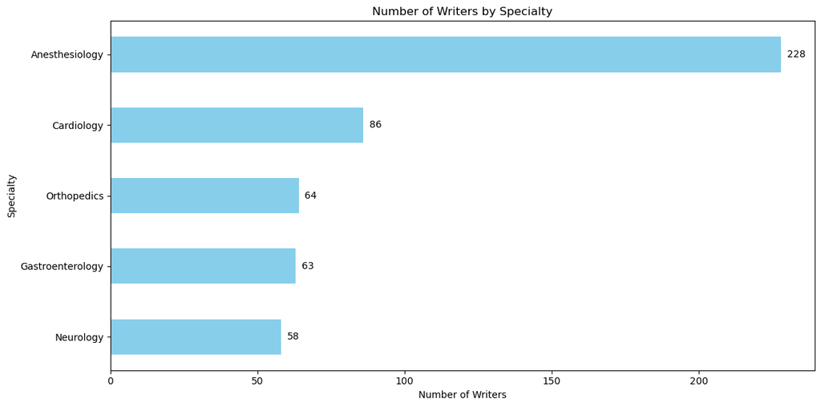

```python
# Sort the data by number of writers for better readability
hcp_trends = hcp_trends.sort_values(by='Writers', ascending=True)

# Plot horizontal bar graph with thinner bars
plt.figure(figsize=(12, 6))
bars = plt.barh(hcp_trends['Specialty'], hcp_trends['Writers'], color='skyblue', height=0.5)

# Add the count on each bar
for bar, count in zip(bars, hcp_trends['Writers']):
    plt.text(bar.get_width() + 2, bar.get_y() + bar.get_height() / 2, str(count), va='center')

plt.title('Number of Writers by Specialty')
plt.xlabel('Number of Writers')
plt.ylabel('Specialty')
plt.tight_layout()
plt.show()
```

What do you observe from the charts above? What would be your actionable recommendations based on your observations?

### Observations from the Charts

#### **Bar Chart: Number of Writers by Specialty**

1. **Anesthesiology Dominance**:
   - With 228 writers, anesthesiologists are the primary prescribers of injectable anesthetics, reinforcing their critical role in market adoption.
2. **Cardiology (86 Writers)**:
   - A significant number of writers come from cardiology, aligning with the dominance of circulatory-related diagnoses.
3. **Orthopedics and Gastroenterology**:
   - These specialties contribute notable numbers of writers (64 and 63, respectively), reflecting opportunities to target procedures in these fields.
4. **Neurology**:
   - With 58 writers, neurology also plays a role, albeit smaller, in prescribing injectable anesthetics.

### Recommendations

#### **1. Intensify Focus on Anesthesiology**

- **Key Drivers**:
  - Anesthesiologists represent the largest prescriber base; securing their loyalty is critical for Product 2's success.
- **Actions**:
  - Organize **specialized workshops and training sessions** for anesthesiologists, emphasizing Product 2's benefits in efficiency and safety.
  - Provide **exclusive incentives** for high-prescribing anesthesiologists, such as loyalty rewards and rebates.
  - Partner with anesthesiology societies and conferences to raise awareness about Product 2.

#### **2. Target Cardiology Specialists**

- **Key Drivers**:
  - The dominance of circulatory system diagnoses (48%) and the high number of cardiology prescribers (86 writers) highlight cardiology as a high-potential market.
- **Actions**:
  - Develop **tailored marketing campaigns** focused on cardiologists, highlighting Product 2's efficacy for cardiovascular procedures.
  - Sponsor cardiovascular conferences and webinars showcasing Product 2’s clinical advantages in circulatory-related surgeries.
  - Collaborate with hospital networks to position Product 2 as the default anesthetic for cardiac surgeries.

#### **3. Expand into Orthopedics and Gastroenterology**

- **Key Drivers**:
  - The musculoskeletal system's 8% share and 64 orthopedic writers suggest a strong opportunity in orthopedic procedures.
  - Gastroenterology's consistent presence (63 writers) presents another growth avenue.
- **Actions**:
  - Position Product 2 as the ideal solution for orthopedic surgeries, emphasizing faster recovery and lower risk.
  - Engage gastroenterologists with targeted educational campaigns on the versatility of Product 2 in diagnostic and therapeutic procedures.
  - Offer bundled discounts for procedures commonly performed by these specialties.

#### **4. Capture New Prescribers**

- **Key Drivers**:
  - Expanding the base of prescribers is critical for reversing Product 2’s decline.
- **Actions**:
  - Identify HCPs in smaller specialties (e.g., neurology, geriatrics) who have yet to adopt Product 2 and engage them with **free trials and introductory pricing**.
  - Use predictive analytics to identify potential high-growth HCPs based on prescribing trends and target them with personalized outreach.

A bar graph showing # patients from each age group using the following age buckets: 18-30, 31-40, 41-50, 51-60, 61-70, 71-80, 81+

```python
claims_que_2.rename(columns={'Age':'Patient_Age'},inplace=True)
```

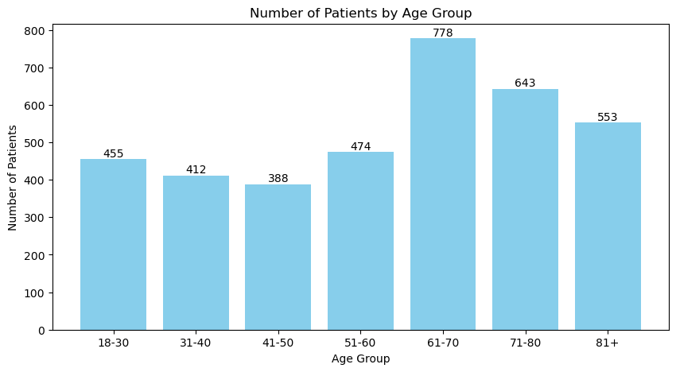

```python
# Define age buckets
bins = [18, 30, 40, 50, 60, 70, 80, np.inf]
labels = ['18-30', '31-40', '41-50', '51-60', '61-70', '71-80', '81+']
claims_que_2['Age_Group'] = pd.cut(claims_que_2['Patient_Age'], bins=bins, labels=labels, right=True)

# Calculate # patients in each age group
patient_distribution = claims_que_2.groupby('Age_Group')['Patient_ID'].nunique().reset_index(name='# Patients')

# Bar graph: # patients by age group
plt.figure(figsize=(10, 5))
bars = plt.bar(patient_distribution['Age_Group'], patient_distribution['# Patients'], color='skyblue')

# Add number of patients on top of each bar
for bar, num in zip(bars, patient_distribution['# Patients']):
    plt.text(bar.get_x() + bar.get_width() / 2, bar.get_height(), f'{num}', ha='center', va='bottom')

plt.title('Number of Patients by Age Group')
plt.xlabel('Age Group')
plt.ylabel('Number of Patients')
plt.show()
```

A bar graph showing percentage of claims from all 4 brands using the same age buckets as above.

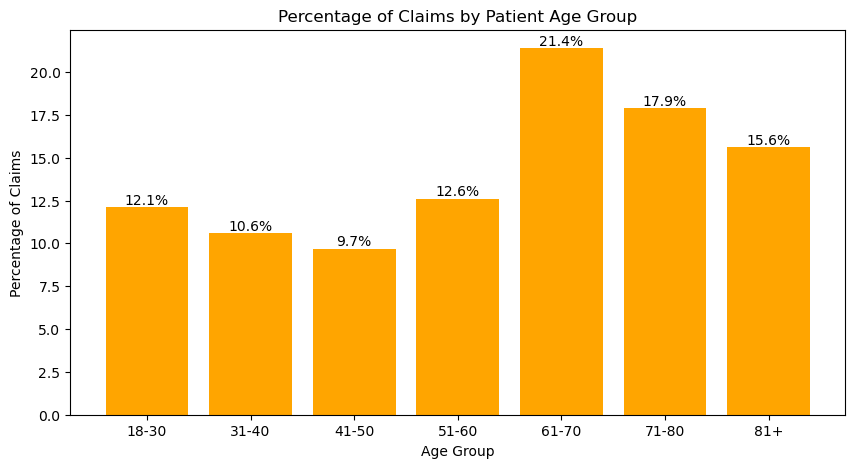

```python
# Calculate % claims in each age group
claim_distribution = claims_que_2.groupby('Age_Group').size().reset_index(name='# Claims')
claim_distribution['% Claims'] = (claim_distribution['# Claims'] / claim_distribution['# Claims'].sum()) * 100

# Round % Claims
claim_distribution['% Claims'] = claim_distribution['% Claims'].round(1)

# Bar graph: % claims by age group
plt.figure(figsize=(10, 5))
bars = plt.bar(claim_distribution['Age_Group'], claim_distribution['% Claims'], color='orange')

# Add % value on top of each bar
for bar, pct in zip(bars, claim_distribution['% Claims']):
    plt.text(bar.get_x() + bar.get_width() / 2, bar.get_height(), f'{pct}%', ha='center', va='bottom')

plt.title('Percentage of Claims by Patient Age Group')
plt.xlabel('Age Group')
plt.ylabel('Percentage of Claims')
plt.show()
```

### Observations from the Charts

#### **Chart 1: Number of Patients by Age Group**

1. **Highest Patient Volume in Older Age Groups**:
   - The **61-70 age group** has the highest number of patients (778), followed by **71-80 (643)** and **81+ (553)**.
   - Older patients dominate the patient population, likely driven by procedures related to chronic conditions or age-related surgeries.
2. **Decline in Younger Age Groups**:
   - The number of patients decreases significantly in younger age groups, with the lowest numbers observed in the **41-50 (388)** and **31-40 (412)** age groups.

### Recommendations

#### **1. Focus on Older Patient Demographics**

- **Key Driver**:
  - Older patients (61+ years) dominate both patient volume and claims, making them the critical demographic for Product 2.
- **Actions**:
  - **Emphasize Safety and Efficacy**:
    - Market Product 2 as a safer and more reliable option for older patients undergoing surgeries, particularly those related to cardiovascular, orthopedic, and general health procedures.
  - **Collaborate with Geriatric HCPs**:
    - Partner with specialists treating older populations, such as cardiologists, orthopedic surgeons, and general practitioners, to promote Product 2.
  - **Address Recovery Times**:
    - Highlight faster recovery times and lower side effects for older patients to differentiate Product 2 from competitors like Product 3.

#### **2. Target High-Claim Age Groups with Tailored Campaigns**

- **61-70 Age Group**:
  - Focus the majority of marketing efforts on the **61-70 age group**, as they contribute the highest claims volume.
  - Develop targeted messaging that showcases Product 2’s suitability for procedures common in this age group, such as joint replacements, cardiac surgeries, and diagnostic interventions.
- **71-80 and 81+ Age Groups**:
  - Emphasize the benefits of Product 2 for frail or high-risk patients, leveraging its safety and efficacy for complex procedures.

#### **3. Engage HCPs Who Serve Older Patients**

- **Key Driver**:
  - HCPs specializing in older patient care are critical to driving claims for Product 2.
- **Actions**:
  - **Education and Training**:
    - Conduct workshops and seminars for anesthesiologists, cardiologists, and orthopedic surgeons on Product 2’s advantages in treating older patients.
  - **Incentive Programs**:
    - Offer rebates or loyalty rewards to HCPs who consistently prescribe Product 2 for older patients.
  - **Collaborate with Long-Term Care Facilities**:
    - Partner with nursing homes and geriatric care centers to integrate Product 2 into their anesthesia protocols.

#### **4. Expand Market Share in Younger Demographics**

- **Key Driver**:
  - Although younger groups contribute less to claims, they represent an untapped market for growth.
- **Actions**:
  - **Promote Versatility**:
    - Highlight Product 2’s applicability for procedures common among younger populations, such as sports injury surgeries (orthopedic) and diagnostic interventions.
  - **Leverage Preventive Procedures**:
    - Target patients undergoing preventive surgeries or exploratory procedures, emphasizing Product 2’s cost-effectiveness.

#### **5. Counter Competitor (Product 3) Growth**

- **Key Driver**:
  - Product 3 likely captures older patients by marketing its efficacy and safety for complex procedures.
- **Actions**:
  - **Head-to-Head Marketing**:
    - Launch campaigns comparing Product 2 to Product 3, focusing on superior recovery times, lower side effects, and cost savings.
  - **Differentiate on Price**:
    - Offer competitive pricing or bundled deals for procedures targeting older demographics to win back market share.

### Expected Outcomes

1. **Increase Claims Volume for Older Patients**:
   - By focusing on the 61+ age groups, Product 2 can capture a larger share of high-volume procedures.
2. **Expand into Younger Age Groups**:
   - Targeted campaigns will open opportunities in underrepresented demographics, increasing overall market share.
3. **Counteract Competitor Dominance**:
   - Differentiating Product 2 based on price and efficacy will mitigate Product 3’s growth.

A clustered bar chart showing # new writers for each brand from each year, where one bar is for one brand, and the bars are grouped into each year from 2016 – 2018. New Writer refers to the HCPs who prescribed the brand for the first time between 2016 and 2018.

```python
# Step 1: Identify first year each HCP wrote for a brand
claims_que_2['First_Year'] = claims_que_2.groupby(['HCP_ID', 'Procedure_Code'])['Year'].transform('min')

# Step 2: Identify new writers by year and brand
new_writers = claims_que_2[claims_que_2['First_Year'] == claims_que_2['Year']]
new_writer_counts = new_writers.groupby(['Procedure_Code', 'Year'])['HCP_ID'].nunique().reset_index(name='New Writers')

# Step 3: Calculate total writers by year and brand
total_writers = claims_que_2.groupby(['Procedure_Code', 'Year'])['HCP_ID'].nunique().reset_index(name='Total Writers')
```

```python
new_writer_counts
```

|  | Procedure_Code | Year | New Writers |
| --- | --- | --- | --- |
| 0 | J1885 | 2016 | 492 |
| 1 | J1885 | 2017 | 7 |
| 2 | J2250 | 2016 | 285 |
| 3 | J2250 | 2017 | 111 |
| 4 | J2250 | 2018 | 34 |
| 5 | J2704 | 2016 | 72 |
| 6 | J2704 | 2017 | 152 |
| 7 | J2704 | 2018 | 140 |
| 8 | J3010 | 2016 | 344 |
| 9 | J3010 | 2017 | 119 |
| 10 | J3010 | 2018 | 32 |

```python
# Pivot the DataFrame for plotting
pivot_df = new_writer_counts.pivot(index='Year', columns='Procedure_Code', values='New Writers')
```

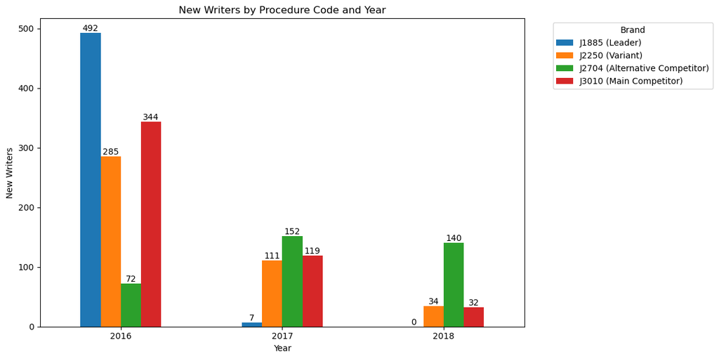

```python
# Re-create pivot_df with the original column labels before modification
pivot_df.columns = ['J1885', 'J2250', 'J2704', 'J3010']

# Update column labels in pivot_df for the legend with the new categories
updated_brand_labels = {
    'J1885': 'J1885 (Leader)',
    'J2250': 'J2250 (Variant)',
    'J2704': 'J2704 (Alternative Competitor)',
    'J3010': 'J3010 (Main Competitor)'
}
pivot_df.columns = [updated_brand_labels[col] for col in pivot_df.columns]

# Plot the bar chart with updated legend
ax = pivot_df.plot(kind='bar', figsize=(12, 6))

# Adding counts on top of each bar
for container in ax.containers:
    ax.bar_label(container, label_type='edge', fontsize=10)

# Adding labels and title
plt.title('New Writers by Procedure Code and Year')
plt.xlabel('Year')
plt.ylabel('New Writers')
plt.xticks(rotation=0)
plt.legend(title='Brand', bbox_to_anchor=(1.05, 1), loc='upper left', fontsize=10)
plt.tight_layout()
plt.show()
```

```python
total_writers
```

|  | Procedure_Code | Year | Total Writers |
| --- | --- | --- | --- |
| 0 | J1885 | 2016 | 492 |
| 1 | J1885 | 2017 | 495 |
| 2 | J1885 | 2018 | 496 |
| 3 | J2250 | 2016 | 285 |
| 4 | J2250 | 2017 | 276 |
| 5 | J2250 | 2018 | 226 |
| 6 | J2704 | 2016 | 72 |
| 7 | J2704 | 2017 | 187 |
| 8 | J2704 | 2018 | 268 |
| 9 | J3010 | 2016 | 344 |
| 10 | J3010 | 2017 | 416 |
| 11 | J3010 | 2018 | 468 |

```python
# Step 4: Calculate continuing writers
continuing_writer_counts = total_writers.merge(new_writer_counts, on=['Procedure_Code', 'Year'], how='left')
continuing_writer_counts['New Writers'] = continuing_writer_counts['New Writers'].fillna(0)
continuing_writer_counts['Continuing Writers'] = continuing_writer_counts['Total Writers'] - continuing_writer_counts['New Writers']
```

```python
continuing_writer_counts
```

|  | Procedure_Code | Year | Total Writers | New Writers | Continuing Writers |
| --- | --- | --- | --- | --- | --- |
| 0 | J1885 | 2016 | 492 | 492.0 | 0.0 |
| 1 | J1885 | 2017 | 495 | 7.0 | 488.0 |
| 2 | J1885 | 2018 | 496 | 0.0 | 496.0 |
| 3 | J2250 | 2016 | 285 | 285.0 | 0.0 |
| 4 | J2250 | 2017 | 276 | 111.0 | 165.0 |
| 5 | J2250 | 2018 | 226 | 34.0 | 192.0 |
| 6 | J2704 | 2016 | 72 | 72.0 | 0.0 |
| 7 | J2704 | 2017 | 187 | 152.0 | 35.0 |
| 8 | J2704 | 2018 | 268 | 140.0 | 128.0 |
| 9 | J3010 | 2016 | 344 | 344.0 | 0.0 |
| 10 | J3010 | 2017 | 416 | 119.0 | 297.0 |
| 11 | J3010 | 2018 | 468 | 32.0 | 436.0 |

```python
# Filter data for years 2017 and 2018
continuing_writer_counts_filtered = continuing_writer_counts[continuing_writer_counts['Year'].isin([2017, 2018])]

# Display the filtered data
continuing_writer_counts_filtered
```

|  | Procedure_Code | Year | Total Writers | New Writers | Continuing Writers |
| --- | --- | --- | --- | --- | --- |
| 1 | J1885 | 2017 | 495 | 7.0 | 488.0 |
| 2 | J1885 | 2018 | 496 | 0.0 | 496.0 |
| 4 | J2250 | 2017 | 276 | 111.0 | 165.0 |
| 5 | J2250 | 2018 | 226 | 34.0 | 192.0 |
| 7 | J2704 | 2017 | 187 | 152.0 | 35.0 |
| 8 | J2704 | 2018 | 268 | 140.0 | 128.0 |
| 10 | J3010 | 2017 | 416 | 119.0 | 297.0 |
| 11 | J3010 | 2018 | 468 | 32.0 | 436.0 |

A line chart showing # of continuing writers for each brand for each year between 2017 and 2018 where each line should belong to each brand. The continuing writers are HCPs who continued to write the brand after the first prescription in the following years.

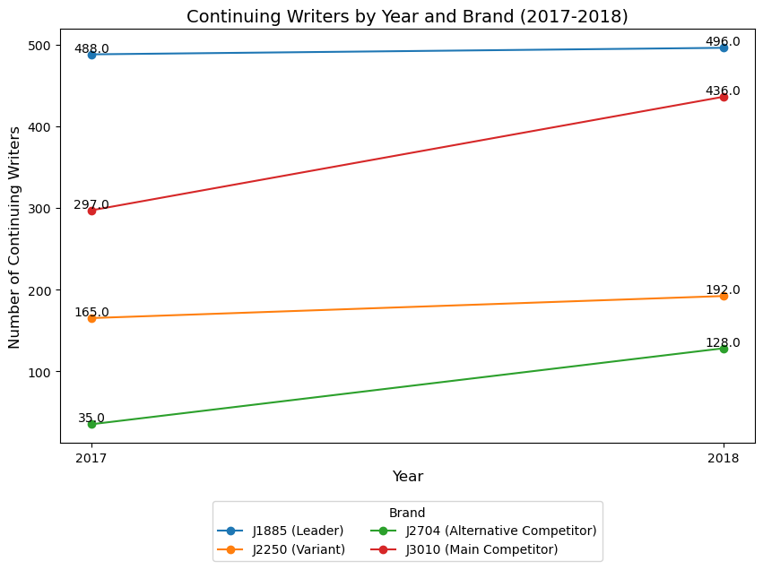

```python
# Line Chart: Continuing Writers by Brand and Year with legend at the bottom
plt.figure(figsize=(10, 6))
for brand in continuing_writer_counts_filtered['Procedure_Code'].unique():
    subset = continuing_writer_counts_filtered[continuing_writer_counts_filtered['Procedure_Code'] == brand]
    plt.plot(
        subset['Year'],
        subset['Continuing Writers'],
        marker='o',
        label=f'{brand} ({("Leader" if brand == "J1885" else "Main Competitor" if brand == "J3010" else "Alternative Competitor" if brand=="J2704" else "Variant")})'
    )
    for x, y in zip(subset['Year'], subset['Continuing Writers']):
        plt.text(x, y, str(y), fontsize=10, ha='center', va='bottom')

# Add titles and labels
plt.title('Continuing Writers by Year and Brand (2017-2018)', fontsize=14)
plt.xlabel('Year', fontsize=12)
plt.ylabel('Number of Continuing Writers', fontsize=12)
plt.xticks([2017, 2018], fontsize=10)  # Ensure only 2017 and 2018 are shown
plt.yticks(fontsize=10)
plt.legend(title='Brand', fontsize=10, loc='lower center', bbox_to_anchor=(0.5, -0.3), ncol=2)
plt.show()
```

### Observations from the Charts

#### **Chart 2: Continuing Writers by Year and Brand**

1. **Stable Continuation for Product 1 (J1885)**:
   - Product 1 retained the highest number of continuing writers (488 in 2017 to 496 in 2018), indicating strong loyalty and consistent market presence.
2. **Product 3 (J3010) Growth in Retention**:
   - Product 3 saw a significant increase in continuing writers, from 297 in 2017 to 436 in 2018, showcasing strong retention and growing loyalty among HCPs.
3. **Product 2 (J2250) Struggles to Retain Writers**:
   - While the number of continuing writers for Product 2 increased slightly from 165 in 2017 to 192 in 2018, this growth is minimal compared to competitors.
   - Retention efforts are falling short, leading to stagnation in market share growth.
4. **Product 4 (J2704) Steady Growth**:
   - The alternative competitor steadily grew its number of continuing writers from 35 in 2017 to 128 in 2018, showing increased HCP adoption.

### Recommendations

#### **1. Re-Engage Lapsed Writers**

- **Target New Writers Lost Since 2016**:
  - Identify and re-engage HCPs who wrote prescriptions for Product 2 in 2016 but did not continue in subsequent years.
  - Use surveys or direct outreach to understand the reasons for attrition and offer tailored incentives to bring them back.
- **Rebuild Momentum Among New Writers**:
  - Implement an aggressive campaign to onboard new writers through **free trials, rebates, and education programs** tailored to their specialties (e.g., anesthesiology, cardiology).

#### **2. Focus on Retaining Existing Writers**

- **Retention Programs**:
  - Launch a loyalty program for existing writers, rewarding consistent use of Product 2 over time.
  - Provide **exclusive discounts or bonuses** to high-volume prescribers.
- **Educational Support**:
  - Offer updated training and resources highlighting Product 2’s efficacy and safety compared to competitors, especially targeting procedures relevant to the writers’ specialties.

#### **3. Counter Product 3’s Growth**

- **Competitive Differentiation**:
  - Highlight Product 2’s advantages over Product 3, such as cost-effectiveness, fewer side effects, or faster onset.
  - Disseminate real-world evidence or testimonials from satisfied HCPs to build trust and credibility.
- **Aggressive Pricing in Key Regions**:
  - Implement dynamic pricing strategies in territories where Product 3 is growing rapidly to make Product 2 more attractive.

#### **4. Leverage Product 4’s Momentum**

- **Collaborate in Niche Segments**:
  - Since Product 4 is growing in niche markets, identify shared specialties where Product 2 could outperform and target those with focused campaigns.
- **Head-to-Head Campaigns**:
  - Use comparative studies to showcase Product 2’s superiority over Product 4 in safety, efficacy, or cost-effectiveness.

#### **5. Expand the New Writer Base**

- **Incentive-Based Outreach**:
  - Provide significant financial incentives for new writers to prescribe Product 2, especially in underpenetrated specialties like gastroenterology and neurology.
- **Data-Driven Targeting**:
  - Use analytics to identify HCPs likely to adopt injectable anesthesia and target them with personalized campaigns.
- **Hospital Partnerships**:
  - Collaborate with hospitals to make Product 2 the default choice for new procedures, onboarding new HCPs as prescribers.

#### **6. Strengthen Relationships with Anesthesiologists**

- **Key Driver**:
  - Anesthesiologists are critical for maintaining and growing Product 2’s market share.
- **Actions**:
  - Partner with anesthesiology associations to develop training programs and sponsor conferences.
  - Offer bundled discounts on Product 2 for high-use hospitals and surgical centers.

### Expected Outcomes

1. **Rebuild Market Share**:
   - Re-engaging lapsed and new writers will help recover market share lost to competitors.
2. **Increase Retention**:
   - Loyalty programs and educational initiatives will ensure continued use among current writers.
3. **Counter Competitive Growth**:
   - Aggressive differentiation and pricing will slow down the growth of Product 3 and Product 4.
4. **Expand New Markets**:
   - Focused efforts on new HCPs and niche segments will create additional opportunities for Product 2.